# Lab 7: Exploratory Data Analysis

Brian Teklits, Charles Doremieux, Andrew MacLean, Clint LaBattaglia

10/13/2019

### Data Description and Handling Missing Values

The dataset describes various electrical quantities taken from a house in France over a period of 4 years. We have information relating to current, voltage, wattage, and readings based on which rooms of the house are consuming power.

To get an idea of the missing values, we first looked at some summaries:

```r
hpc %>%
  filter(is.na(Voltage)) %>%
  group_by(Date) %>%
  count() %>%
  arrange(desc(n))
```

```
## # A tibble: 82 x 2
## # Groups:   Date [82]
##    Date           n
##    <date>     <int>
##  1 2007-04-29  1440
##  2 2009-06-14  1440
##  3 2010-01-13  1440
##  4 2010-08-18  1440
##  5 2010-08-19  1440
##  6 2010-08-20  1440
##  7 2010-08-21  1440
##  8 2010-09-26  1440
##  9 2010-09-27  1440
## 10 2007-04-28  1419
## # ... with 72 more rows
```

Multiple days have 1440 missing values, which corresponds to an entire day without power. We chose to drop these days from the data as they provide no information whatsoever.

```r
off_all_day <- hpc %>%
  filter(is.na(Voltage)) %>%
  group_by(Date) %>%
  count() %>%
  filter(n == 1440)

hpc2 <- hpc %>%
  anti_join(off_all_day, by = "Date")
```

Then, we looked at the remaining missing values:

```r
outages <- hpc2 %>%
  filter(is.na(Voltage)) %>%
  group_by(Date) %>%
  count() %>%
  arrange(desc(n))
outages
```

```
## # A tibble: 73 x 2
## # Groups:   Date [73]
##    Date           n
##    <date>     <int>
##  1 2007-04-28  1419
##  2 2009-06-13  1410
##  3 2010-08-22  1288
##  4 2010-03-20  1208
##  5 2010-09-25  1204
##  6 2010-09-28  1153
##  7 2010-01-14  1142
##  8 2009-08-13   891
##  9 2007-04-30   864
## 10 2010-03-21   819
## # ... with 63 more rows
```

We split these into two groups: those with more than 6 minutes of lost data in a day, and those under that threshold. We guessed that the shorter gaps in data might represent measurement malfunctions or errors, which could be filled in from the previous minute’s measurements without substantially changing the data. Longer delays could indicate power outages: these could be dropped if desired.

We decided to handle these cases individually based on the questions we looked to answer.

### Individual Sections

#### Brian

From the UCI website, we’re given a formula which can calculate the energy consumption for all electrical equipment not included in the submetering 1,2, or 3 categories. I’ll refer to this quantity as “other energy usage”.

**Question:** What conclusions can we reach about this other energy usage? What appliances might it measure?

**Answer:** The largest contribution to other energy usage is likely central heating. Defining high usage as minutes measured at over 30 watt-hours, roughly representing the top 5% of measurements, I found that the 6 Fall and Winter months (October through March), make up the top 6 in high usage minutes. The top 5 of these are more than double the number of minutes of any Spring or Summer month.

```r
hpc_other_energy <- hpc2 %>%
  mutate(other_energy = (Global_active_power*1000/60 - Sub_metering_1 - Sub_metering_2 - Sub_metering_3))

hpc_other_energy %>%
  filter(other_energy > 30) %>%
  group_by(month) %>%
  summarise(count = n()) %>%
  arrange(desc(count))
```

```
## # A tibble: 12 x 2
##    month count
##    <int> <int>
##  1     1 20295
##  2    12 19726
##  3     2 14415
##  4    11 12971
##  5     3 11731
##  6    10  9034
##  7     4  5448
##  8     9  4768
##  9     5  3796
## 10     6  1799
## 11     8  1312
## 12     7  1094
```

The top day of high usage minutes in the dataset is December 31, 2006:

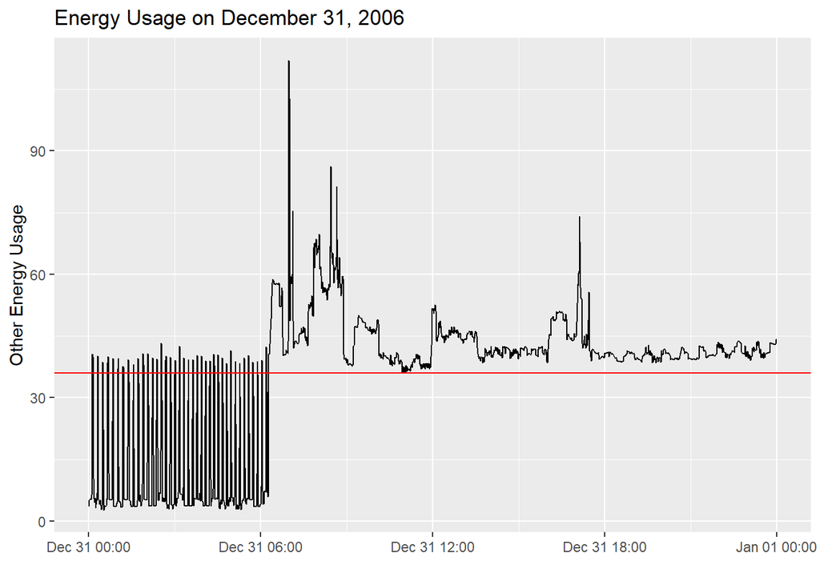

```r
top_day <- hpc_other_energy %>%
  filter(year == 2006, month == 12,day == 31)
ggplot(top_day) +
  geom_line(aes(datetime, other_energy)) +
  ggtitle("Energy Usage on December 31, 2006") +
  ylab("Other Energy Usage") +
  xlab("")+
  geom_hline(aes(yintercept=36),color="red")
```

In the early morning, before waking up, the only energy usage is central heating. Upon waking up, other appliances are put into use, but we still see the same baseline level of usage from the heater throughout the entire day.

**Why the Question is interesting:** Rather than taking a pre-defined quantity where we know what the measurements represent, we do the opposite. We calculate the other energy usage, and attempt to analyse what it represents.

**How did you formulate the question:** First, I used a mutate to add the new variable, then ran a few filters to get an idea of what ranges of values it took. Settling on 30 as a reasonable value for high usage, I then ran some summaries on months and days to determine the dates of highest usage. Finally, I plotted a variety of high usage days to get an idea of what similarities they had, settling on the above plot.

**Benefit of this analysis:** A frugal homeowner might use this data to justify turning the thermostat down a few extra degrees overnight, in order to save on energy usage.

#### Clint

**Question:** What does the proportion of total average energy use by each group of metered appliances tell us about the energy use of the household?

**Answer** The miscellaneous power drain which likely represents heating for the home was consistently using the most electricity. Interestingly, during the summer months the proportion of power use consumed by this subsection decreases and the proportion of power consumed by the water heater and air conditioner rise accordingly.

```r
mean_global <- hpc2 %>%
  group_by(month)%>%
  summarise(Mean_global= mean(Global_active_power, na.rm = TRUE))

mean_1 <- hpc2 %>%
  group_by(month)%>%
  summarise(Mean_sub_1= mean(Sub_metering_1, na.rm = TRUE))%>%
  mutate(avg_use_1 = (Mean_sub_1*60)/1000)


mean_2 <- hpc2 %>%
  group_by(month)%>%
  summarise(Mean_sub_2= mean(Sub_metering_2, na.rm = TRUE))%>%
  mutate(avg_use_2 = (Mean_sub_2*60)/1000)



mean_3 <- hpc2 %>%
  group_by(month) %>%
  summarise(Mean_sub_3= mean(Sub_metering_3, na.rm = TRUE))%>%
  mutate(avg_use_3 = (Mean_sub_3*60)/1000)
```

```r
miss_energy <- hpc2 %>%
  select(month, Global_active_power, Sub_metering_1, Sub_metering_2, Sub_metering_3) %>%
  group_by(month)%>%
  mutate(other_energy = (Global_active_power*1000/60 - Sub_metering_1 - Sub_metering_2 - Sub_metering_3))

avg_other <- miss_energy %>%
  summarise(mean_other= mean(other_energy, na.rm = TRUE))%>%
  mutate(prep_other= (mean_other*60)/1000)
```

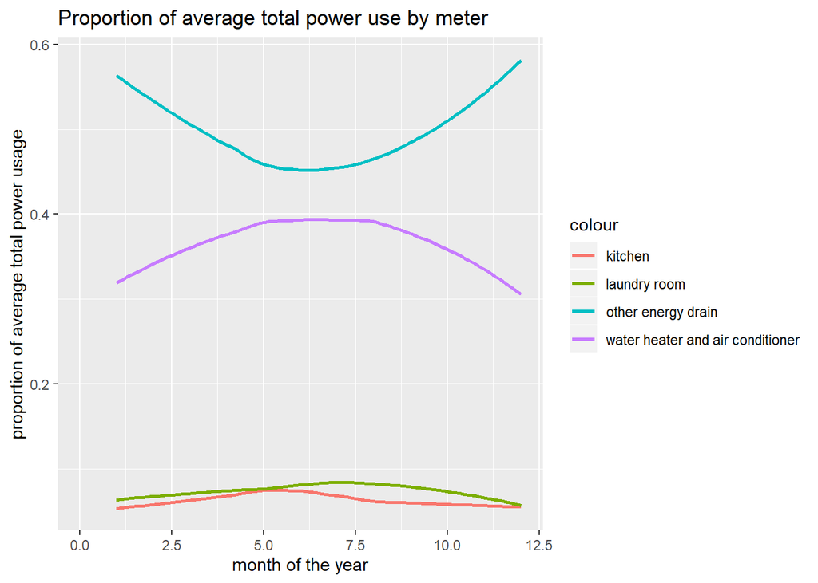

```r
experiment <- cbind(avg_other,mean_1,mean_2,mean_3,mean_global)

experiment <- experiment[, !duplicated(colnames(experiment))]

prop_test <- experiment%>%
  mutate(prop_1 = avg_use_1/Mean_global)%>%
  mutate(prop_2 = avg_use_2/Mean_global)%>%
  mutate(prop_3 = avg_use_3/Mean_global)%>%
  mutate(prop_other = prep_other/Mean_global)

prop_test_graph <- prop_test%>%
  select(month,prop_1, prop_2, prop_3, prop_other)

ggplot(data = prop_test_graph, mapping =  aes(x = month)) +
  geom_smooth(mapping = aes(y= prop_1, color = 'kitchen'), se=FALSE) +
  geom_smooth(mapping = aes(y = prop_2, color = 'laundry room'), se=FALSE) +
  geom_smooth(mapping = aes(y= prop_3, color = 'water heater and air conditioner'), se=FALSE) +
  geom_smooth(mapping = aes(y = prop_other, color = 'other energy drain'), se=FALSE) +
  xlab("month of the year") +
  ylab("proportion of average total power usage") +
  ggtitle("Proportion of average total power use by meter")+
  xlim(0,12)
```

**Why the Question is interesting:** This question is interesting because it shows how the amount of power each group of metered appliances related to the total amount of electricity consumed by the household.

**How did you formulate the question:** Initially I was curious to know how much power each metered group of appliances was using in comparison to each other, so I first converted each set into the same unit type as the global active power. After this I decided to use months as my grouping for analysis as this would yeild only 12 values which seemed more managable while still providing a useful frame for analysis. From there I found the average energy consumption for each month and then divided the average use for each metered group by the mean global energy use.

**Benefit of this analysis:** This analysis revealed that the kitchen and laundry room consume a relatively small proportion of the electricty used by the home, which may be useful in deciding on whether or not to purchase more energy efficient appliances in those rooms as opposed to the water heater and air conditioner or heating apparatus.

#### Charles

**Question:** Building from the observation that central heating is most likely the most resource expensive utility, my goal is to track which elements of the house are the lease resource costly. How often is the laundry room, which contains a washing-machine, a tumble-drier, a refrigerator and a light more resource expensive than the kitchen and climate control? why?

```r
# Include Plot and Summary Statistic
sub_1 <- hpc_other_energy %>%
  filter(Sub_metering_2 > Sub_metering_1, Sub_metering_2 > Sub_metering_3) %>%
  group_by(month) %>%
  summarise(count = n()) %>%
  arrange(desc(count))
sub_1
```

```
## # A tibble: 12 x 2
##    month count
##    <int> <int>
##  1     7 33750
##  2     3 29035
##  3     6 28774
##  4     9 27181
##  5    10 25541
##  6     5 25225
##  7     8 24196
##  8     4 23960
##  9    11 22679
## 10     1 22308
## 11     2 20471
## 12    12 18281
```

This shows that the months where laundry room usage and refregirator usage surpass climate control are typically fairer months of the year. This makes intuitive sense because those months require less climate control, and kitchen usage (oven, dishwasher) are limited typically to imediately after food is prepared or eaten. Hence, on months where heat and ac are not always running, consumption is comprised in great part by the second class of submetering.

[figure not shown]

```r
hpc3 <- hpc2 %>% mutate(active_energy = Global_active_power * 1000/60)
hpc3 <- hpc3 %>% mutate(sub_1 = Sub_metering_1/active_energy)
hpc3 <- hpc3 %>% mutate(sub_2 = Sub_metering_2/active_energy)
hpc3 <- hpc3 %>% mutate(sub_3 = Sub_metering_3/active_energy)

ggplot(hpc3) +
        geom_smooth(mapping = aes(x = month, y = Sub_metering_2)) + ggtitle("Laundry/Fridge Power Usage as Percent of Total Power Usage") + xlab("Month") + ylab("Laundry Room, Fridge, Light") + theme_minimal() + scale_x_continuous(breaks = seq(0, 12, 1))
```

**Why the Question is interesting:** This question is interesting because it provides perspective on which aspects of our home-lives should be the focus of scrutiny when it comes to resource costs. If the cost of cooking and food production is minimal compared to other resources, perhaps this can guide what solutions are available to households planning to cut down costs.

**How did you formulate the question:** I created new variables to determine the consumption of each room for each minute. Then I was able to graph my variable of interest, which was the submetering of 2. From that I was able to receive insight into my question.

**Benefit of this analysis:** The analysis provides the benefit of understanding for the consumption of the second sub metering. It develops further how consumption changes each month.

#### Andrew

**Question:** How does the range of values for Voltage change between winter and summer months through all 4 years.

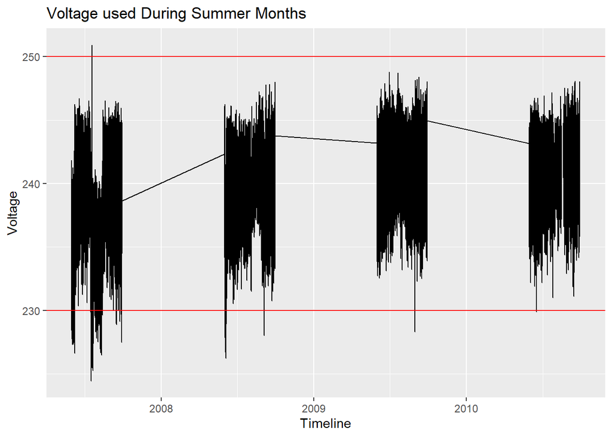

```r
Summermonths <- hpc2 %>%
  filter(month >= 6 & month <=9)

Wintermonths <- hpc2 %>%
  filter(month ==12 | month <= 2)

ggplot(Summermonths)+
  geom_line(mapping = aes(x= Date, y = Voltage))+
  ggtitle("Voltage used During Summer Months") +
  ylab("Voltage") +
  xlab("Timeline")+
  geom_hline(aes(yintercept=250),color="red")+
  geom_hline(aes(yintercept=230),color="red")
```

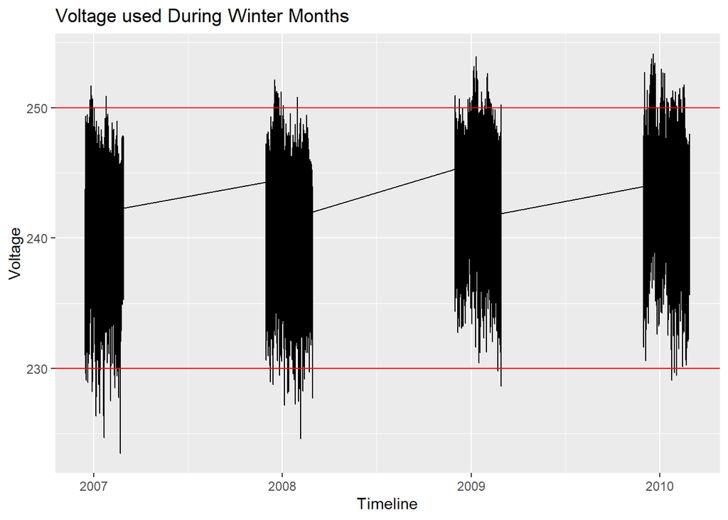

```r
ggplot(Wintermonths)+
  geom_line(mapping = aes(x= Date, y = Voltage))+
  ggtitle("Voltage used During Winter Months")+
  ylab("Voltage") +
  xlab("Timeline")+
  geom_hline(aes(yintercept=250),color="red")+
  geom_hline(aes(yintercept=230),color="red")
```